# Week 12 Simulations Problem Set

Sami Cemek

## Exercise 1: Blood pressure sampling distribution

Suppose systolic blood pressure in healthy adults has a normal distribution with mean 112 mmHg and standard deviation 10 mmHg.

1. Simulate one sample of 20 adults according to the theoretical distribution given above and find the average blood pressure in the sample. Save the average blood pressure in a variable, then print the result.

```r
#sample size = 20, mean = 112, sd = 10.

set.seed(7)
sample1 <- rnorm(20, mean=112, sd=10)
averageBloodPressure <- mean(sample1, na.rm = TRUE)
print(averageBloodPressure)
```

```
## [1] 116.4325
```

2. Use a for loop to simulate 1000 samples (each of 20 adults) and find the average blood pressure in each of the thousand samples. Save these averages in a vector called `sample_means`. Your final result of sample_means should be a numeric vector with 1000 values (each value is the mean of a single simulated sample).

```r
sample_meansq1 <- numeric(1000)

for (i in 1:1000){
  sample1 <- rnorm(20, mean=112, sd=10)
  averageBloodPressure <- mean(sample1, na.rm = TRUE)

  #For Test Purposes, run this:
  #print(paste("Sample mean:", averageBloodPressure, "looped", i, "times"))

  sample_meansq1[i] <- averageBloodPressure
}

#For Test Purposes, run this:
#sample_meansq1
```

3. Create a histogram of the sample means. This is a graph of the **Sampling Distribution of Sample Mean** blood pressures.

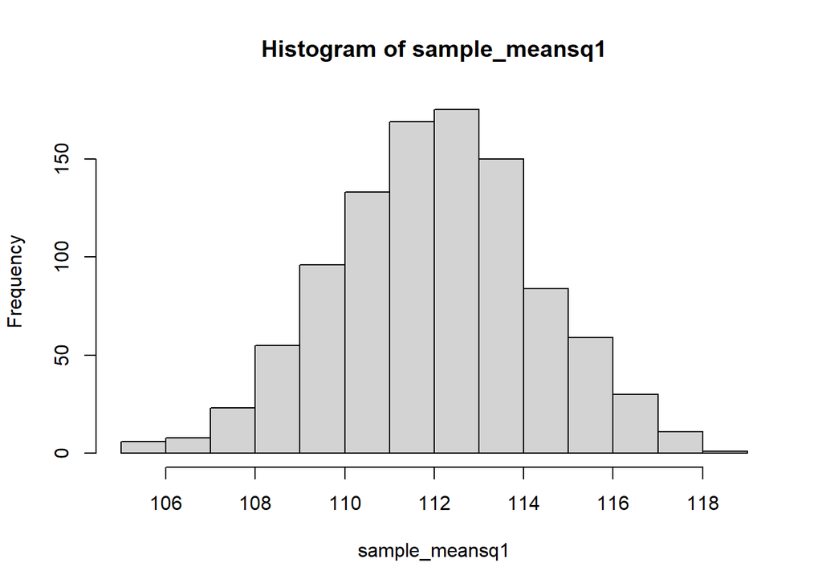

```r
hist(sample_meansq1)
```

## Exercise 2: Real data samples

Let’s work with the RockandRoll2019 data in the Lock5Data package. This data set contains information on every inductee in the Rock and Roll Hall of Fame (up through 2019 at least).

Note that, while we may mostly think of famous singers or bands in the Rock and Roll Hall of Fame, many of the people are not actually rock performers at all– some are early influencers, others are sidemen or non-performers, etc. There are several possible categories.

1. Use R to select a random sample of 10 inductees. Save this as `rockandroll10`.

```r
set.seed(7)
rockandroll10 <- sample_n(RockandRoll2019, size = 10)
rockandroll10
```

```
##                           Inductee FemaleMembers        Category People
## 1  Tom Petty and the Heartbreakers            No       Performer      6
## 2                  The "5" Royales            No Early Influence      5
## 3                   Paul McCartney            No       Performer      1
## 4              Simon and Garfunkel            No       Performer      2
## 5                      Roy Orbison            No       Performer      1
## 6     Gerry Goffin and Carole King           Yes   Non-performer      2
## 7                    The Yardbirds            No       Performer      5
## 8                      Albert King            No       Performer      1
## 9                        Jeff Beck            No       Performer      1
## 10                    The Coasters            No       Performer      4
```

2. Use a for loop to print out the name and number of people for each inductee in your sample.

```r
for(i in 1:nrow(rockandroll10)){
  print(paste("Inductee:",rockandroll10$Inductee[i],"-", "Number of People:", rockandroll10$People[i]))
}
```

```
## [1] "Inductee: Tom Petty and the Heartbreakers - Number of People: 6"
## [1] "Inductee: The \"5\" Royales - Number of People: 5"
## [1] "Inductee: Paul McCartney - Number of People: 1"
## [1] "Inductee: Simon and Garfunkel - Number of People: 2"
## [1] "Inductee: Roy Orbison - Number of People: 1"
## [1] "Inductee: Gerry Goffin and Carole King - Number of People: 2"
## [1] "Inductee: The Yardbirds - Number of People: 5"
## [1] "Inductee: Albert King - Number of People: 1"
## [1] "Inductee: Jeff Beck - Number of People: 1"
## [1] "Inductee: The Coasters - Number of People: 4"
```

```r
#Extra Credit
#print(paste("Name:", rockandroll10$Inductee,"-", "Number of People:", rockandroll10$People))
```

3. Review of data wrangling– use `summarize()` or another R function to find the proportion of inductees in your sample who are in the category “Performer”.

```r
performerCat <- rockandroll10 %>%
  summarize(PerformerNum = sum(Category == "Performer"))

#Total number of groups
TotalNum <- nrow(rockandroll10)

print(TotalNum)
```

```
## [1] 10
```

```r
print(performerCat$PerformerNum)
```

```
## [1] 8
```

```r
#Proportion of the Performer in the data set
(performerCat$PerformerNum)/TotalNum
```

```
## [1] 0.8
```

```r
performerCat
```

```
##   PerformerNum
## 1            8
```

4. Simulation. Use a for loop to simulate taking many different random samples from the data set, where each sample has 10 inductees. For each sample, calculate the proportion of inductees who are performers. Save your results in a numeric vector called `sample_props`. You should simulate at least 1000 random samples, so there are at least 1000 values in `sample_props.`

```r
sample_props <- numeric(1000)

for (i in 1:1000){
  rockandroll10 <- sample_n(RockandRoll2019, size = 10)

  performerCat <- rockandroll10 %>%
  summarize(PerformerNum = sum(Category == "Performer"))

  #Total number of groups
  TotalNum <- nrow(rockandroll10)

  #Proportion of the Performer in the data set
  proportion <- (performerCat$PerformerNum)/TotalNum

  sample_props[i] <- proportion
}
#For Test Purposes, run this:
#sample_props
```

5. Make a boxplot of `sample_props`.

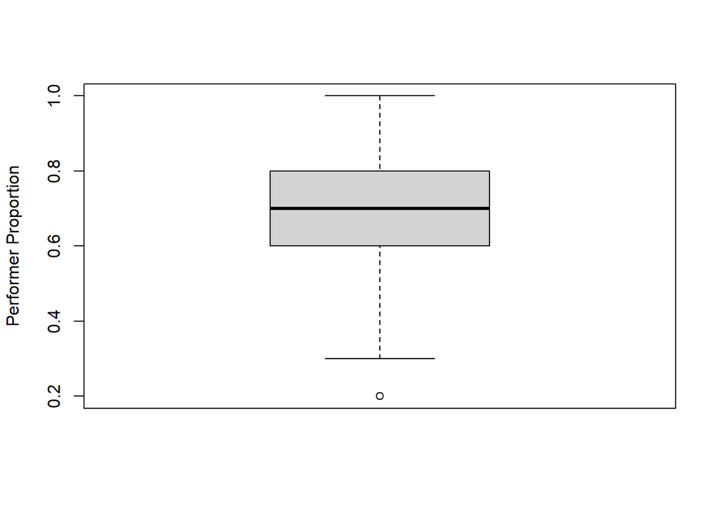

```r
boxplot(sample_props, ylab = "Performer Proportion")
```

## Exercise 3: Functions and For Loops

Inspired by R for Data Science, Exercise 21.2.1.3.

Do you know the children’s nursery rhyme “10 in the bed”? It goes like this:

10  
There were 10 in the bed  
And the little one said  
“Roll over, roll over.”  
So they all rolled over and one fell out.

9 There were 9 in the bed…

(and so on, until there are 0 kids in the bed)

Let’s combine our knowledge of functions and for loops to write this song.

1. Write a function called `n_bed()` that takes in an integer input (e.g. 10) and prints out the lyrics to one verse of the rhyme using that number.

```r
n_bed <- function(number){
  print(number)
  print(cat(paste("There were", number, "in the bed
And the little one said
'Roll over, roll over.'
So they all rolled over and one fell out.")))

}


n_bed(1)
```

```
## [1] 1
## There were 1 in the bed
## And the little one said
## 'Roll over, roll over.'
## So they all rolled over and one fell out.NULL
```

2. Pick a starting number (e.g. 5). Then write a for loop that will print the lyrics for the full rhym until there are no kids left in the bed.

```r
n_bed <- function(number){
  for (i in 0:number){
    print(number)
    print(cat(paste("There were", number, "in the bed
And the little one said
'Roll over, roll over.'
So they all rolled over and one fell out.")))
  number = number - 1
}
}

n_bed(5)
```

```
## [1] 5
## There were 5 in the bed
## And the little one said
## 'Roll over, roll over.'
## So they all rolled over and one fell out.NULL
## [1] 4
## There were 4 in the bed
## And the little one said
## 'Roll over, roll over.'
## So they all rolled over and one fell out.NULL
## [1] 3
## There were 3 in the bed
## And the little one said
## 'Roll over, roll over.'
## So they all rolled over and one fell out.NULL
## [1] 2
## There were 2 in the bed
## And the little one said
## 'Roll over, roll over.'
## So they all rolled over and one fell out.NULL
## [1] 1
## There were 1 in the bed
## And the little one said
## 'Roll over, roll over.'
## So they all rolled over and one fell out.NULL
## [1] 0
## There were 0 in the bed
## And the little one said
## 'Roll over, roll over.'
## So they all rolled over and one fell out.NULL
```

## OPTIONAL Intermediate Exercise 4: Efficient for loops

Inspired by R for Data Science, Exercise 21.2.1.4.

It’s common to see for loops that don’t preallocate the output and instead increase the length of a vector at each step. For instance, compare the following two loops.

Option 1:

```r
# create empty output vector that is 10 spaces long
my_means <- numeric(10)

# Run the for loop 10 times
for (i in 1:10){
  my_means[i] <- mean(rnorm(100), mean = i)
}
```

Option 2:

```r
# create empty output vector that is 0 spaces long...
my_means <- numeric(0)

# Run the for loop 10 times (and change the length of my_means to match)
for (i in 1:10) {
  my_means <- c(my_means, mean(rnorm(100), mean = i))
}
my_means
```

```
##  [1] -0.041523869  0.008175727  0.034509654 -0.129148826 -0.149405055
##  [6] -0.133396429 -0.048390836 -0.014232832  0.051013659 -0.065579305
```

Which option is more efficient? Explain your reasoning, and then try to devise code to test your theory using microbenchmark or Sys.time().